# Introduction

# Introduction to MiscMetabar: an R package to facilitate visualization and reproducibility in metabarcoding analysis

## Raison d’être

- Complete R packages dada2 and phyloseq
- Useful visualizations (`biplot_pq`, `circle_pq`, `upset_pq`, `ggvenn_pq`)
- Facilitate the use of targets package

## Quick overview

For an introduction to metabarcoding in R, Please visite the [state of the field](https://adrientaudiere.github.io/MiscMetabar/articles/states_of_fields_in_R.html) vignettes. The [import, export and track](https://adrientaudiere.github.io/MiscMetabar/articles/import_export_track.html) vignette explains how import and export `phyloseq` object. Its also show how to summarize useful information (number of sequences, samples and clusters) across bioinformatic pipelines.

If you are interested in ecological metrics, see the vignettes describing [alpha-diversity](https://adrientaudiere.github.io/MiscMetabar/articles/alpha-div.html) and [beta-diversity](https://adrientaudiere.github.io/MiscMetabar/articles/beta-div.html) analysis. The vignette [filter taxa and samples](https://adrientaudiere.github.io/MiscMetabar/articles/filter.html) describes some data-filtering processes using MiscMetabar and the [reclustering](https://adrientaudiere.github.io/MiscMetabar/articles/Reclustering.html) tutorial introduces the different way of clustering already-clustered OTU/ASV. The vignette [tengeler](https://adrientaudiere.github.io/MiscMetabar/articles/tengeler.html) explore the dataset from Tengeler et al. (2020) using some MiscMetabar functions.

For developers, I also wrote a vignette describing som [rules of codes](https://adrientaudiere.github.io/MiscMetabar/articles/Rules.html).

### Summarize a physeq object

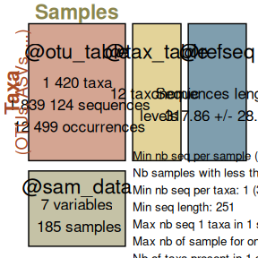

```r
library("MiscMetabar")
library("phyloseq")
data("data_fungi")
summary_plot_pq(data_fungi)
```

### Create an interactive table of the tax_table

```r
data("GlobalPatterns", package = "phyloseq")
tax_datatable(subset_taxa(
  GlobalPatterns,
  rowSums(GlobalPatterns@otu_table) > 100000
))
```

|  | Kingdom | Phylum | Class | Order | Family | Genus | Species | nb_seq |
| --- | --- | --- | --- | --- | --- | --- | --- | --- |
| 12812 | Bacteria | Actinobacteria | Actinobacteria | koll13 |  |  |  | 196550 |
| 317658 | Bacteria | Actinobacteria | Actinobacteria | Actinomycetales | ACK-M1 |  |  | 234024 |
| 329744 | Bacteria | Actinobacteria | Actinobacteria | Actinomycetales | ACK-M1 |  |  | 436539 |
| 471141 | Bacteria | Actinobacteria | Actinobacteria | Actinomycetales | Micrococcaceae | Rothia | Rothiamucilaginosa | 104260 |
| 326977 | Bacteria | Actinobacteria | Actinobacteria | Bifidobacteriales | Bifidobacteriaceae | Bifidobacterium | Bifidobacteriumadolescentis | 291577 |
| 64396 | Bacteria | Fusobacteria | Fusobacteria | Fusobacteriales | Fusobacteriaceae | Fusobacterium |  | 155864 |
| 317182 | Bacteria | Cyanobacteria | Chloroplast | Stramenopiles |  |  |  | 528629 |
| 549656 | Bacteria | Cyanobacteria | Chloroplast | Stramenopiles |  |  |  | 2481214 |
| 327536 | Bacteria | Cyanobacteria | Chloroplast | Stramenopiles |  |  |  | 143627 |
| 340216 | Bacteria | Cyanobacteria | Chloroplast | Stramenopiles |  |  |  | 104199 |

[output cut: 32 more lines]

### Sankey diagram of the tax_table

```r
gp <- subset_taxa(GlobalPatterns, GlobalPatterns@tax_table[, 1] == "Archaea")
sankey_pq(gp, taxa = c(1:5))
```

[interactive chart not shown]

### Upset plot for visualize distribution of taxa in function of samples variables

```r
if (packageVersion("ggplot2") < "4.0.0") {
  upset_pq(gp, "SampleType", taxa = "Class")
}
```

[output not shown]

# References

Tengeler, A.C., Dam, S.A., Wiesmann, M. et al. Gut microbiota from persons with attention-deficit/hyperactivity disorder affects the brain in mice. Microbiome 8, 44 (2020). https://doi.org/10.1186/s40168-020-00816-x